# FA24 STAT340 Midterm take-home portion

## Q1 - Testing

Infinity Cable (fictional) manufactures fiber optic cable for industrial purposes. They have three manufacturing facilities in Alderwood, Brentwick and Coppergrove. A recent quality control audit sampled various 1 kilometer lengths of cable from the three facilities and counted the number of flaws in the cables:

```r
cables = data.frame(
  site = rep(c("Alderwood","Brentwick","Coppergrove"), times=c(53,48,51)),
  flaws = c(6,4,4,1,2,1,4,2,4,3,4,8,2,4,6,2,4,1,2,2,0,2,5,2,3,3,3,2,5,4,4,
            1,4,3,5,4,4,3,3,4,0,3,4,4,3,5,3,2,1,1,2,3,4,2,5,1,2,2,3,1,2,3,
            0,4,2,4,2,2,2,4,4,2,3,5,2,3,2,2,3,1,3,1,1,1,1,0,3,4,4,4,2,2,4,
            3,3,2,1,7,3,1,1,3,6,3,7,4,2,3,1,0,4,1,3,4,8,3,3,1,4,3,3,2,2,3,
            3,1,0,4,6,3,3,3,7,3,4,3,2,2,4,3,1,4,1,5,3,3,2,3,3,1,3,1)
)
```

Your job is to perform a comparison using the testing techniques we’ve covered in this course to see if there is evidence that the facilities actually produce cable of different quality. Do not use techniques we have not covered in this course.

1. (2pts) A colleague suggests that we should focus our attention on a comparison of Alderwood and Brentwick (ignoring Coppergrove), since they seem to have the largest gap in average number of flaws. Why specifically would this not be a good approach?
2. Now you will perform the test. You should
   1. (1pt) State your null and alternative hypotheses,
   2. (1pt) decide on the test statistic to use,
   3. (1pt) state whether this is a one or two-sided test, and explain why,
   4. (2pts) produce a simulated distribution for your test statistic under the null hypothesis
   5. (2pts) calculate the $p$-value
   6. (1pt) make your conclusion

*Hint: your test statistic should somehow compare all 3 groups. There are many possible statistics you could use. If you are stuck consider a statistic based on the site means or the site variances.*

> *PLEASE WRITE YOUR WORK BELOW:*

```r
# insert code here

# b) iv) v)

set.seed(123)

calculate_sad <- function(data) {
  sites <- unique(data$site)
  combinations <- combn(sites, 2)
  sad <- sum(apply(combinations, 2, function(pair) {
    abs(mean(data$flaws[data$site == pair[1]]) - mean(data$flaws[data$site == pair[2]]))
  }))
  return(sad)
}

observed_sad <- calculate_sad(cables)

num_replicates <- 1000
simulated_sad <- replicate(num_replicates, {
  shuffled_data <- cables
  shuffled_data$flaws <- sample(shuffled_data$flaws)
  calculate_sad(shuffled_data)
})

p_value <- mean(simulated_sad >= observed_sad)

cat(sprintf("Observed sum of absolute differences: %f\n", observed_sad))
```

```
## Observed sum of absolute differences: 1.268082
```

```r
cat(sprintf("P-value: %f\n", p_value))
```

```
## P-value: 0.113000
```

```r
if (p_value < 0.05) {
  cat("Reject H0: There is a significant difference in the number of flaws between the facilities.\n")
} else {
  cat("Fail to reject H0: There is no significant difference in the number of flaws between the facilities.\n")
}
```

```
## Fail to reject H0: There is no significant difference in the number of flaws between the facilities.
```

*write discussion here*

> 1. Focusing only on Alderwood and Brentwick while ignoring Coppergrove is not a good approach because it excludes relevant data, leading to biased analysis and potentially false conclusions. Coppergrove’s data might provide critical context or reveal overarching trends across all facilities that could explain the differences. Analyzing only two facilities reduces the validity of the results and contradicts standard statistical principles, which require using all relevant data to ensure robust and accurate comparisons.
> 1. H0: There is no difference in the average number of flaws between the three facilities (Alderwood, Brentwick, and Coppergrove). The sum of the absolute differences in the means of each pair of facilities is equal to zero. HA: At least one of the facilities has a different average number of flaws compared to the others. The sum of the absolute differences in the means of the pairs of facilities is not equal to zero.
> 2. The test statistic I will use is the sum of the absolute differences in the mean number of flaws between each pair of facilities: |mean(Alderwood) - mean(Brentwick)| + |mean(Alderwood) - mean(Coppergrove)| + |mean(Brentwick) - mean(Coppergrove)|
> 3. This is a two-sided test because the null hypothesis suggests that there is no difference in the average number of flaws between the three facilities (i.e., the test statistic equals zero). The alternative hypothesis, on the other hand, suggests that there is a difference in the average number of flaws, indicating that at least one facility differs from the others. A two-sided test is appropriate because we are interested in detecting differences in either direction (i.e., whether one facility has more or fewer flaws than another).
> 4. code above
> 22. P-value: 0.113000
> 6. Based on the calculated p-value of 0.113, which is greater than the significance level of 0.05, we fail to reject the null hypothesis (H0). This means that there is no significant difference in the number of flaws between the three manufacturing facilities (Alderwood, Brentwick, and Coppergrove). Therefore, we do not have sufficient evidence to suggest that the facilities produce cable with different levels of quality.

> As a check for my work, I will use Anova test, which is a statistical technique used to compare the means of three or more groups.

```r
anova_test <- aov(flaws ~ site, data = cables)
summary(anova_test)
```

```
##              Df Sum Sq Mean Sq F value Pr(>F)
## site          2   11.6   5.794   2.383 0.0958 .
## Residuals   149  362.3   2.431
## ---
## Signif. codes:  0 '***' 0.001 '**' 0.01 '*' 0.05 '.' 0.1 ' ' 1
```

> Since the p-value (0.0958) is greater than the commonly used significance level of 0.05, we fail to reject the null hypothesis. Anova test agrees with my solution above.

## Q2 - Estimation

Let $X_i$ be i.i.d random variables following continuous Uniform($-a,a$) for some unknown positive parameter $a$. Suppose you draw the following sample of $n=15$ observations:

```r
data = c(-1.97, -1.07, 0.61, 3.43, -2.51, 3.35, 3.74, 1.35,
         1.08, -3.68, -2.47, -2.72, 1.57, -0.97, 2.27)
```

1. (3pts) Using what you know about estimation, find a reasonable point estimator $\hat a$. Explain why you think this gives a reasonable estimate of the parameter $a$.
   - Note: you do NOT need to find the BEST estimator to earn full points on this part (or later parts), just one that can be argued to be reasonable.
2. (2pts) Apply your estimator to the given sample data. What is your point estimate for $a$?
3. (3pts) Using the MC method shown in class, compute **and interpret** a 95% confidence interval for $a$. Also, *briefly* (1-2 sentences) explain how well you think this interval would actually perform.
4. (2pts) Just for this part d, suppose the true value of $a$ is actually 3.9. Use MC to approximately estimate the bias of your estimator.

> *PLEASE WRITE YOUR WORK BELOW:*

```r
# insert code here

# a) and b)
n <- length(data)
a_hat_unbiased <- (n + 1) / n * max(abs(data))
a_hat_unbiased
```

```
## [1] 3.989333
```

```r
# c)
set.seed(123)

num_simulations <- 10000

unbiased_estimators <- numeric(num_simulations)

for (i in 1:num_simulations) {
  simulated_sample <- runif(n, min = -a_hat_unbiased, max = a_hat_unbiased)
  unbiased_estimators[i] <- (n + 1) / n * max(abs(simulated_sample))
}

# Calculate the 95% confidence interval
lower_bound <- quantile(unbiased_estimators, 0.025)
upper_bound <- quantile(unbiased_estimators, 0.975)

cat("The 95% confidence interval for the parameter 'a' is (", round(lower_bound, 2), ", ", round(upper_bound, 2), ")\n")
```

```
## The 95% confidence interval for the parameter 'a' is ( 3.31 ,  4.25 )
```

```r
# d)
set.seed(123)

true_a <- 3.9
n <- 15

num_simulations <- 10000

unbiased_estimators <- numeric(num_simulations)

for (i in 1:num_simulations) {

  simulated_sample <- runif(n, min = -true_a, max = true_a)
  unbiased_estimators[i] <- (n + 1) / n * max(abs(simulated_sample))
}

bias <- mean(unbiased_estimators) - true_a

cat("The approximate bias of the estimator when the true value of 'a' is", true_a, "is", bias, "\n")
```

```
## The approximate bias of the estimator when the true value of 'a' is 3.9 is -0.002082025
```

*write discussion here*

> 1. Explanation: In the class example we have learned that a = max{xi} is not the good point estimator. It was shown that its value was not within its 95% CI. I chose unbiased point estimator (n+1)/n abs{Xi} as point estimator because we have Uniform($-a,a$) distribution with equal lower and upper bound.
> 3. The 95% confidance interval for my point parameter is (3.31, 4.25). Due to simmetry it is the same for the lower bound with negative signs. I think it perform well because value of point estimator is in the interval.

## Q3 - Regression

In R, the built-in dataset `USArrests` contains 1975 estimates of rates (per 100,000 people) of various types of crimes in each US state (source: the World Almanac). Consider the `Assault` and `Murder` columns as X and Y variables:

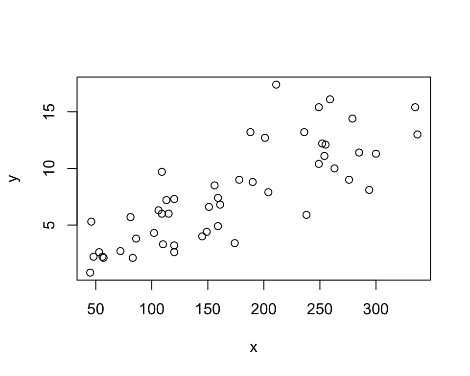

```r
x = USArrests$Assault
y = USArrests$Murder
plot(x,y)
```

1. (2pts) Does this look like a reasonable dataset to fit a linear model to? Explain why or why not.
2. (2pts) Regardless of your answer to part a, fit a linear model to this data. Show the summary print out with the full table of coefficients.
3. (2pts) Does this result show a significant relation between x,y? Answer why or why not and give a p-value.
4. (2pts) Give a 95% confidence interval for the true slope.
5. (2pts) Make the standard diagnostic plot(s) for the residuals. Does this fit look reasonable? Explain why or why not.

> *PLEASE WRITE YOUR WORK BELOW:*

```r
# insert code here

# b)

model <- lm(Murder ~ Assault, data = USArrests)

summary(model)
```

```
##
## Call:
## lm(formula = Murder ~ Assault, data = USArrests)
##
## Residuals:
##     Min      1Q  Median      3Q     Max
## -4.8528 -1.7456 -0.3979  1.3044  7.9256
##
## Coefficients:
##             Estimate Std. Error t value Pr(>|t|)
## (Intercept) 0.631683   0.854776   0.739    0.464
## Assault     0.041909   0.004507   9.298  2.6e-12 ***
## ---
## Signif. codes:  0 '***' 0.001 '**' 0.01 '*' 0.05 '.' 0.1 ' ' 1
##
## Residual standard error: 2.629 on 48 degrees of freedom
## Multiple R-squared:  0.643,  Adjusted R-squared:  0.6356
## F-statistic: 86.45 on 1 and 48 DF,  p-value: 2.596e-12
```

```r
# d)
confint(model, level = 0.95)
```

```
##                   2.5 %     97.5 %
## (Intercept) -1.08695906 2.35032438
## Assault      0.03284621 0.05097104
```

```r
# check
t_critical <- qt(0.975, df = 48)

lower_bound <- 0.041909 - t_critical * 0.004507
upper_bound <- 0.041909 + t_critical * 0.004507
c(lower_bound, upper_bound)
```

```
## [1] 0.03284707 0.05097093
```

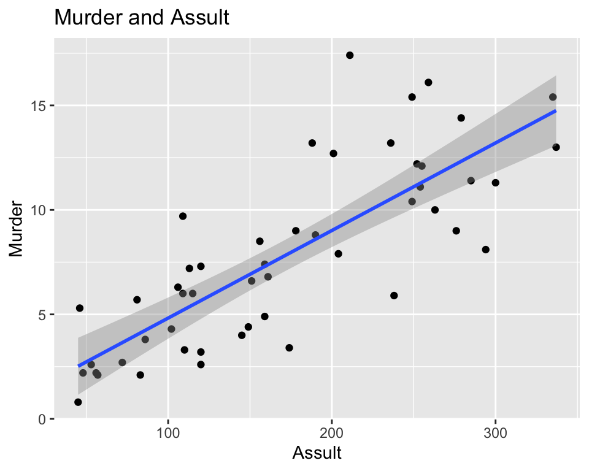

```r
# e)
library(ggplot2)
#plot the line
pp <- ggplot( model,
              aes(x=USArrests$Assault,y=USArrests$Murder));
pp <- pp +geom_point() + geom_smooth(method="lm",
                                     formula="y~x",
                                     se=TRUE);
pp <- pp + labs( x="Assult",
                 y="Murder",
                 title="Murder and Assult" )
pp
```

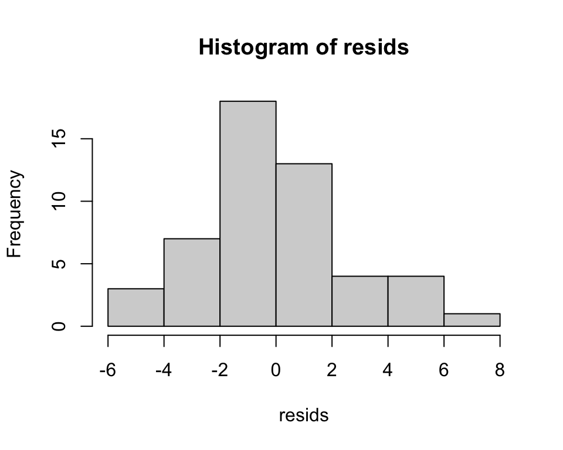

```r
#residuals
resids <- residuals(model)
hist(resids)
```

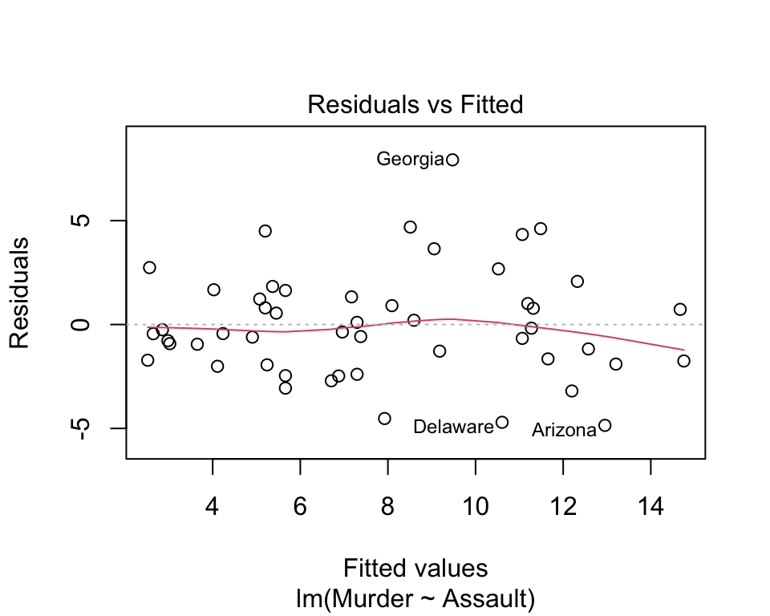

```r
#Homoscedasticity
plot(model, which=1)
```

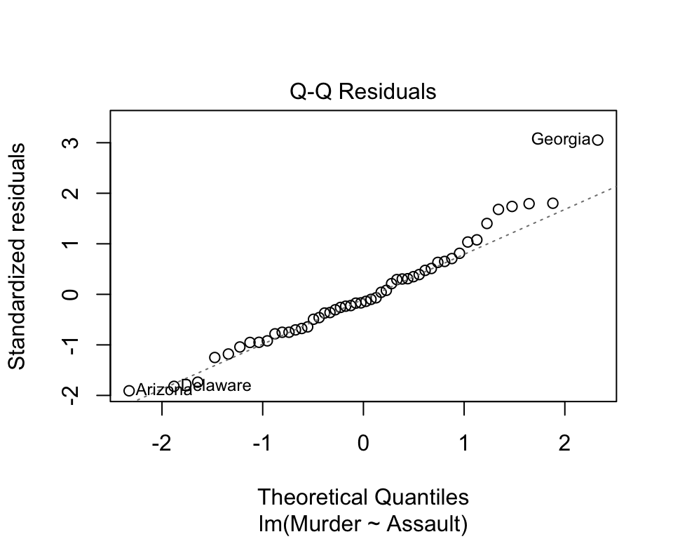

```r
plot(model, which=2)
```

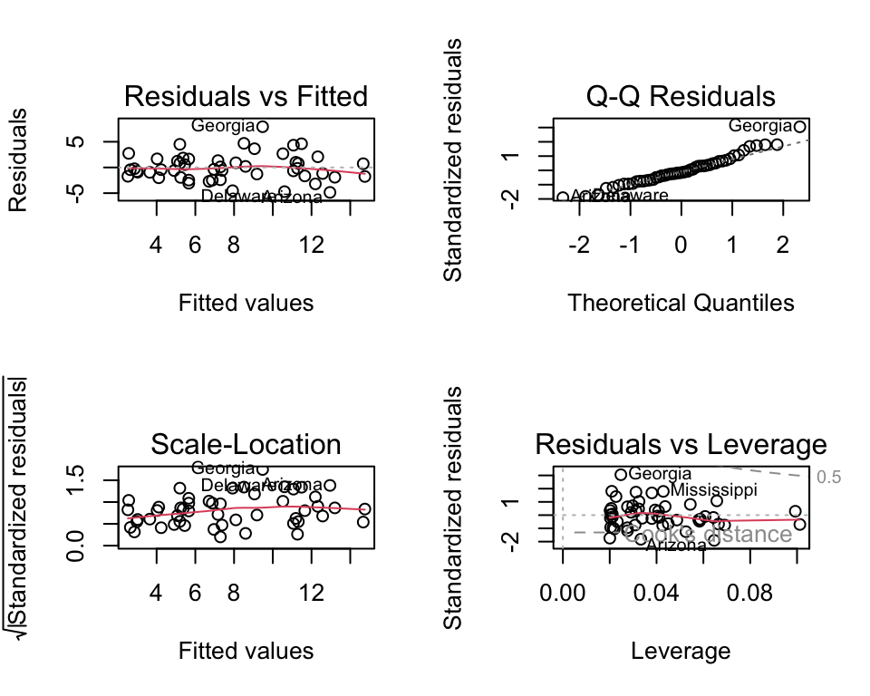

```r
#all standard diagnostic
par(mfrow = c(2, 2))
plot(model)
```

*write discussion here*